# Self-Driving Car Engineer Nanodegree

## Project: Build a Traffic Sign Recognition Classifier

In this notebook, a template is provided for you to implement your functionality in stages, which is required to successfully complete this project. If additional code is required that cannot be included in the notebook, be sure that the Python code is successfully imported and included in your submission if necessary.

In addition to implementing code, there is a writeup to complete. The writeup should be completed in a separate file, which can be either a markdown file or a pdf document. There is a [write up template](https://github.com/udacity/CarND-Traffic-Sign-Classifier-Project/blob/master/writeup_template.md) that can be used to guide the writing process. Completing the code template and writeup template will cover all of the [rubric points](https://review.udacity.com/#!/rubrics/481/view) for this project.

The [rubric](https://review.udacity.com/#!/rubrics/481/view) contains "Stand Out Suggestions" for enhancing the project beyond the minimum requirements. The stand out suggestions are optional. If you decide to pursue the "stand out suggestions", you can include the code in this Ipython notebook and also discuss the results in the writeup file.

> **Note:** Code and Markdown cells can be executed using the **Shift + Enter** keyboard shortcut. In addition, Markdown cells can be edited by typically double-clicking the cell to enter edit mode.

## Step 0: Load The Data

```python
# Load pickled data
import pickle

# Load saved the training, validation and testing data

training_file = 'train.p'
validation_file= 'valid.p'
testing_file = 'test.p'

with open(training_file, mode='rb') as f:
    train = pickle.load(f)
with open(validation_file, mode='rb') as f:
    valid = pickle.load(f)
with open(testing_file, mode='rb') as f:
    test = pickle.load(f)

# Separate features and labels
X_train, y_train = train['features'], train['labels']
X_valid, y_valid = valid['features'], valid['labels']
X_test, y_test = test['features'], test['labels']

# Make sure that the feature and label lenghts are the same
assert(len(X_train) == len(y_train))
assert(len(X_valid) == len(y_valid))
assert(len(X_test) == len(y_test))
```

## Step 1: Dataset Summary & Exploration

The pickled data is a dictionary with 4 key/value pairs:

- `'features'` is a 4D array containing raw pixel data of the traffic sign images, (num examples, width, height, channels).
- `'labels'` is a 1D array containing the label/class id of the traffic sign. The file `signnames.csv` contains id -> name mappings for each id.
- `'sizes'` is a list containing tuples, (width, height) representing the original width and height the image.
- `'coords'` is a list containing tuples, (x1, y1, x2, y2) representing coordinates of a bounding box around the sign in the image. **THESE COORDINATES ASSUME THE ORIGINAL IMAGE. THE PICKLED DATA CONTAINS RESIZED VERSIONS (32 by 32) OF THESE IMAGES**

Complete the basic data summary below. Use python, numpy and/or pandas methods to calculate the data summary rather than hard coding the results. For example, the [pandas shape method](http://pandas.pydata.org/pandas-docs/stable/generated/pandas.DataFrame.shape.html) might be useful for calculating some of the summary results.

### Provide a Basic Summary of the Data Set Using Python, Numpy and/or Pandas

```python
### Replace each question mark with the appropriate value.
### Use python, pandas or numpy methods rather than hard coding the results
import numpy as np

# Number of training examples
n_train = len(X_train)

# Number of validation examples
n_valid = len(X_valid)

# Number of testing examples.
n_test = len(X_test)

# Shape of a single image
image_shape = X_train[0].shape

# Number of unique classes/labels in the dataset.
n_classes = len(np.unique(y_train))

print("Number of training examples =", n_train)
print("Number of validation examples =", n_valid)
print("Number of testing examples =", n_test)
print("Image data shape =", image_shape)
print("Number of classes =", n_classes)
```

```
Number of training examples = 34799
Number of validation examples = 4410
Number of testing examples = 12630
Image data shape = (32, 32, 3)
Number of classes = 43
```

### Include an exploratory visualization of the dataset

Visualize the German Traffic Signs Dataset using the pickled file(s). This is open ended, suggestions include: plotting traffic sign images, plotting the count of each sign, etc.

The [Matplotlib](http://matplotlib.org/) [examples](http://matplotlib.org/examples/index.html) and [gallery](http://matplotlib.org/gallery.html) pages are a great resource for doing visualizations in Python.

**NOTE:** It's recommended you start with something simple first. If you wish to do more, come back to it after you've completed the rest of the sections.

```
Labels in order from top left to bottom right [0-42]:
```

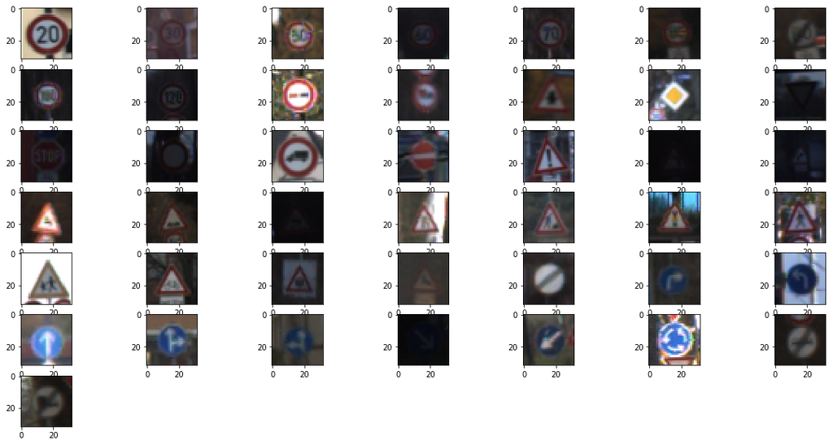

```python
import matplotlib.pyplot as plt

# Visualizations will be shown in the notebook.
%matplotlib inline

# Show an example image for each label
print('Labels in order from top left to bottom right [0-42]:')
plt.subplots(figsize=(20, 10))
for i in range(0,43):
    index = np.where(y_train==i)[0][0]
    plt.subplot(7,7, 1 + i)
    plt.imshow(X_train[index,:,:,:])
```

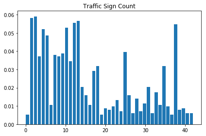

```python
# Plot of the percentage of occurrance for each label in the training set
fig, ax = plt.subplots()

# Create a histogram
bins = np.linspace(0,42,44)
ax.hist(y_train, bins, normed=1, histtype='bar', rwidth=0.8)
ax.set_title('Traffic Sign Count')

fig.tight_layout()
plt.show()
```

## Step 2: Design and Test a Model Architecture

Design and implement a deep learning model that learns to recognize traffic signs. Train and test your model on the [German Traffic Sign Dataset](http://benchmark.ini.rub.de/?section=gtsrb&subsection=dataset).

The LeNet-5 implementation shown in the classroom at the end of the CNN lesson is a solid starting point. You'll have to change the number of classes and possibly the preprocessing, but aside from that it's plug and play!

With the LeNet-5 solution from the lecture, you should expect a validation set accuracy of about 0.89. To meet specifications, the validation set accuracy will need to be at least 0.93. It is possible to get an even higher accuracy, but 0.93 is the minimum for a successful project submission.

There are various aspects to consider when thinking about this problem:

- Neural network architecture (is the network over or underfitting?)
- Play around preprocessing techniques (normalization, rgb to grayscale, etc)
- Number of examples per label (some have more than others).
- Generate fake data.

Here is an example of a [published baseline model on this problem](http://yann.lecun.com/exdb/publis/pdf/sermanet-ijcnn-11.pdf). It's not required to be familiar with the approach used in the paper but, it's good practice to try to read papers like these.

### Pre-process the Data Set (normalization, grayscale, etc.)

Use the code cell (or multiple code cells, if necessary) to implement the first step of your project.

```python
from sklearn.utils import shuffle
from skimage.color import rgb2gray
from skimage.filters import gaussian
import skimage.transform as transform
from sklearn import preprocessing
from scipy import ndimage
from random import random
import math

def normalize_grayscale(image_data):
    """
    Normalize the image data with Min-Max scaling to a range of [-1, 1]
    :param image_data: The image data to be normalized
    :return: Normalized image data
    """
    mean = np.mean(image_data)
    std = np.std(image_data)
    image_data = (image_data - mean) / std
    maximum = np.amax(image_data)
    minimum = np.amin(image_data)
    a = -1
    b = 1
    #grayscale_min = 0
    #grayscale_max = 1
    image_output = a + ( ( (image_data - minimum)*(b - a) )/( maximum - minimum ) )

    return image_output
```

```python
# Conversion to grayscale of the training set
X_train = rgb2gray(X_train)


# Conversion to grayscale of the validation set
X_valid = rgb2gray(X_valid)


# Conversion to grayscale of the test set
X_test = rgb2gray(X_test)
```

```
Labels in order from top left to bottom right [0-42]:
```

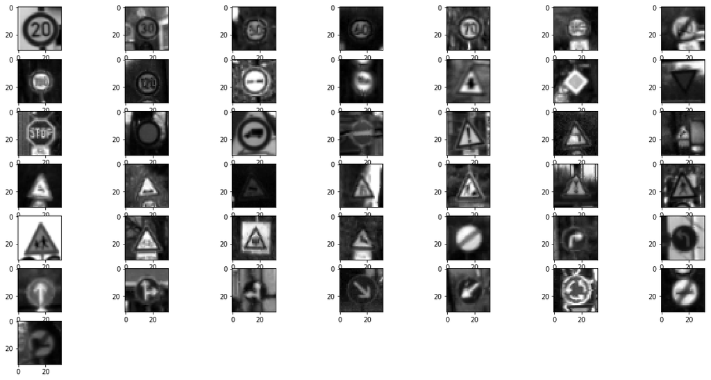

```python
# Show an example image for each label after grayscaling
print('Labels in order from top left to bottom right [0-42]:')
plt.subplots(figsize=(20, 10))
for i in range(0,43):
    index = np.where(y_train==i)[0][0]
    plt.subplot(7,7, 1 + i)
    plt.imshow(X_train[index,:,:], cmap='gray')
```

```python
# Normalization of the training set
X_train = normalize_grayscale(X_train)

# Normalization of the validation set
X_valid = normalize_grayscale(X_valid)

# Normalization of the test set
X_test = normalize_grayscale(X_test)
```

```
Labels in order from top left to bottom right [0-42]:
```

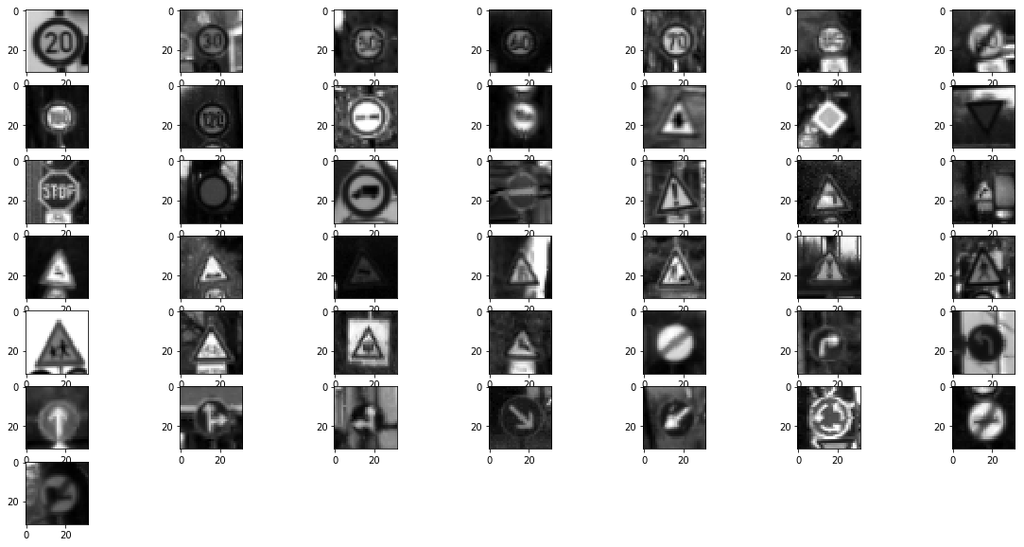

```python
# Show an example image for each label after normalization
print('Labels in order from top left to bottom right [0-42]:')
plt.subplots(figsize=(20, 10))
for i in range(0,43):
    index = np.where(y_train==i)[0][0]
    plt.subplot(7,7, 1 + i)
    plt.imshow(X_train[index,:,:], cmap='gray')
```

```python
# Add axis loast during grayscale conversion
X_train = X_train[:, :, :, np.newaxis]
X_valid = X_valid[:, :, :, np.newaxis]
X_test = X_test[:, :, :, np.newaxis]
```

```python
# The label occurrance in the training set is quite unequal. To avoid
# biasing against the most numerous, we will duplicate some of the less
# frequent images

# Example:
# Most repeated label: 4, 2010 times
# Label 15 is present 190 times
# We will duplicate each image np.round_(2010/190) = 11
# As a result we will have 2090 Label 15 images

# Create a dictionary with the number of times we want to duplicate each label
unique, counts = np.unique(y_train, return_counts=True)
max_count = np.amax(counts)*2
dictionary = dict(zip(unique, np.round_(max_count/counts)))

# Calculate new total number of images
total_count = np.sum(counts*np.round_(max_count/counts))

# Initialize new dataset variables
X_train_mod = np.zeros((int(total_count),32,32,1))
y_train_mod = np.zeros((int(total_count)))

# Loop through each image in the training dataset, duplicating it the desired
# amount of times
i=0
c=0
for image in X_train:
    repetitions = dictionary[y_train[i]]
    for b in range (0,int(repetitions)):
        X_train_mod[c] = image
        y_train_mod[c] = y_train[i]
        c +=1
    i+=1

# Assign the new dataset to the training dataset variables
X_train = X_train_mod
y_train = y_train_mod
```

```
Number of training examples = 168833
```

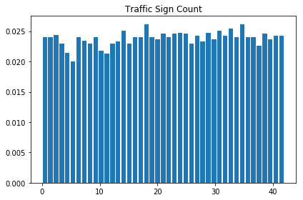

```python
# Print final training set size
# Number of training examples
n_train = len(X_train)
print("Number of training examples =", n_train)

# Plot of the percentage of occurrance for each label in the training set
fig, ax = plt.subplots()

# Create a histogram.
bins = np.linspace(0,42,44)
ax.hist(y_train, bins, normed=1, histtype='bar', rwidth=0.8)
ax.set_title('Traffic Sign Count')

fig.tight_layout()
plt.show()

# Note: we can see now a much more equal distribution of labels
```

```
Images before image augmentation
```

[figure not shown]

```
Images after image augmentation
```

[figure not shown]

```python
from keras.preprocessing.image import ImageDataGenerator

# Suffle the training data to avoid overfitting
# Note: This is not strictly neccessary, as the image gerator will
# later do this for us
X_train, y_train = shuffle(X_train, y_train)

# Create ImageDataGenerator for example batch: Every time it's called, it will add random variations
# to the original images, preventing overfitting, specially after we duplicated some
# of the original images
datagen_example = ImageDataGenerator(width_shift_range=0.05,
    height_shift_range=0.05,
    zoom_range=0.1)

# Fit example batch to the ImageDataGenerator
datagen_example.fit(X_train[0:9,:,:,:])

# Plot images before ImageDataGenerator
print("Images before image augmentation")
for i in range(0, 9):
        plt.subplot(330 + 1 + i)
        plt.imshow(X_train[i].reshape(32, 32), cmap=plt.get_cmap('gray'))
    # show the plot
plt.show()

# Plot images after ImageDataGenerator
print("Images after image augmentation")
# Test:
# Configure batch size and retrieve example batch of images
for X_batch, y_batch in datagen_example.flow(X_train[0:9,:,:,:], y_train[0:9], batch_size=9):
    # create a grid of 3x3 images
    for i in range(0, 9):
        plt.subplot(330 + 1 + i)
        plt.imshow(X_batch[i].reshape(32, 32), cmap=plt.get_cmap('gray'))
    # show the plot
    plt.show()
    break


# Create ImageDataGenerator: Every time it's called, it will add random variations
# to the original images, preventing overfitting, specially after we duplicated some
# of the original images
datagen = ImageDataGenerator(width_shift_range=0.05,
    height_shift_range=0.05,
    zoom_range=0.1)

# Fit example dataset to the ImageDataGenerator
datagen.fit(X_train)
```

### Model Architecture

```python
import tensorflow as tf

# Define maximum number of epochs. We will be using early stop, so
# this is set to very high number
EPOCHS = 100

# Define Batch Size.
BATCH_SIZE = 512
```

```python
from tensorflow.contrib.layers import flatten
from tf_utils import weight_variable, bias_variable, dense_to_one_hot

# Spatial transformer library. Author: David Dao
# https://github.com/daviddao/spatial-transformer-tensorflow
from spatial_transformer import transformer


# Arguments used for tf.truncated_normal, randomly defines variables for the weights and biases for each layer
mu = 0
sigma = 0.1

# Weights and biases definition
weights = {
    'wc1': tf.Variable(tf.truncated_normal([5,5,1,108],mu,sigma)),
    'wc2': tf.Variable(tf.truncated_normal([5,5,108,108],mu,sigma)),
    'wd1': tf.Variable(tf.truncated_normal([23868,100],mu,sigma)),
    'wd2': tf.Variable(tf.truncated_normal([100,100],mu,sigma)),
    'out': tf.Variable(tf.truncated_normal([100,43],mu,sigma))}

biases = {
    'bc1': tf.Variable(tf.truncated_normal([108],mu,sigma)),
    'bc2': tf.Variable(tf.truncated_normal([108],mu,sigma)),
    'bd1': tf.Variable(tf.truncated_normal([100],mu,sigma)),
    'bd2': tf.Variable(tf.truncated_normal([100],mu,sigma)),
    'out': tf.Variable(tf.truncated_normal([43],mu,sigma))}

# Placeholder fro Dropout probability
keep_prob = tf.placeholder(tf.float32)

#Placeholder for learning rate
rate = tf.placeholder(tf.float32)

# Weights and variables for spatial transformer
W_fc_loc1 = weight_variable([1024, 20])
b_fc_loc1 = bias_variable([20])
W_fc_loc2 = weight_variable([20, 6])
# Use identity transformation as starting point
initial = np.array([[1., 0, 0], [0, 1., 0]])
initial = initial.astype('float32')
initial = initial.flatten()
b_fc_loc2 = tf.Variable(initial_value=initial, name='b_fc_loc2')

# Model definition
def convNet(x):

    # Spatial transformer implementation
    # Define the two layer localisation network
    h_fc_loc1 = tf.nn.tanh(tf.matmul(flatten(x), W_fc_loc1) + b_fc_loc1)
    # We can add dropout for regularizing and to reduce overfitting like so:
    h_fc_loc1_drop = tf.nn.dropout(h_fc_loc1, keep_prob)
    # Second layer
    h_fc_loc2 = tf.nn.tanh(tf.matmul(h_fc_loc1_drop, W_fc_loc2) + b_fc_loc2)
    # We'll create a spatial transformer module to identify discriminative
    # patches
    out_size = (32, 32)
    h_trans = transformer(x, h_fc_loc2, out_size)

    # Layer 1: Convolutional. Input = 32x32x1. Output = 28x28x108.
    conv1 = tf.nn.conv2d(h_trans, weights['wc1'], strides=[1, 1, 1, 1], padding='VALID',name='conv1')
    conv1_bias = tf.nn.bias_add(conv1, biases['bc1'])
    # Activation.
    conv1_act = tf.nn.tanh(conv1_bias)
    # Pooling. Input = 28x28x108. Output = 14x14x108.
    conv1_maxpool = tf.nn.max_pool(conv1_act, ksize=[1, 2, 2, 1], strides=[1, 2, 2, 1], padding='VALID',name='conv1_maxpool')
    # Layer 2: Convolutional. Output = 10x10x108.
    conv2 = tf.nn.conv2d(conv1_maxpool, weights['wc2'], strides=[1, 1, 1, 1], padding='VALID',name='conv2')
    conv2_bias = tf.nn.bias_add(conv2, biases['bc2'])
    # Activation.
    conv2_act = tf.nn.tanh(conv2_bias)
    # Pooling. Input = 10x10x108. Output = 5x5x108.
    conv2_maxpool = tf.nn.max_pool(conv2_act, ksize=[1, 2, 2, 1], strides=[1, 2, 2, 1], padding='VALID',name='conv2_maxpool')
    # Flatten. Input = 5x5x108 + 14x14x108 . Output = 23868.
    fc0 = tf.concat([flatten(conv2_maxpool),flatten(conv1_maxpool)],1)
    # Layer 3: Fully Connected. Input = 23868. Output = 100.
    fc1 = tf.add(tf.matmul(fc0,weights['wd1']), biases['bd1'])
    # Activation.
    fc1 = tf.nn.tanh(fc1)
    fc1 = tf.nn.dropout(fc1,keep_prob,name='fc1')
    # Layer 4: Fully Connected. Input = 100. Output = 100.
    fc2 = tf.add(tf.matmul(fc1,weights['wd2']), biases['bd2'])
    # Activation.
    fc2 = tf.nn.tanh(fc2)
    fc2 = tf.nn.dropout(fc2,keep_prob,name='fc2')
    # TODO: Layer 5: Fully Connected. Input = 100. Output = 43.
    logits = tf.add(tf.matmul(fc2,weights['out']), biases['out'])
    return logits
```

### Train, Validate and Test the Model

A validation set can be used to assess how well the model is performing. A low accuracy on the training and validation sets imply underfitting. A high accuracy on the training set but low accuracy on the validation set implies overfitting.

```python
# Placeholder for the dataset
x = tf.placeholder(tf.float32, (None, 32, 32, 1))
y = tf.placeholder(tf.int32, (None))
one_hot_y = tf.one_hot(y, 43)
```

```python
logits = convNet(x)
softmax = tf.nn.softmax(logits)
cross_entropy = tf.nn.softmax_cross_entropy_with_logits(logits=logits, labels=one_hot_y)
loss_operation = tf.reduce_mean(cross_entropy)
optimizer = tf.train.AdamOptimizer(learning_rate = rate)
training_operation = optimizer.minimize(loss_operation)
```

```python
result_prediction = tf.argmax(logits, 1)
correct_prediction = tf.equal(tf.argmax(logits, 1), tf.argmax(one_hot_y, 1))
accuracy_operation = tf.reduce_mean(tf.cast(correct_prediction, tf.float32))
saver = tf.train.Saver()

def evaluate(X_data, y_data):
    num_examples = len(X_data)
    total_accuracy = 0
    sess = tf.get_default_session()
    for offset in range(0, num_examples, BATCH_SIZE):
        batch_x, batch_y = X_data[offset:offset+BATCH_SIZE], y_data[offset:offset+BATCH_SIZE]
        accuracy = sess.run(accuracy_operation, feed_dict={x: batch_x, y: batch_y, keep_prob: 1})
        total_accuracy += (accuracy * len(batch_x))
    return total_accuracy / num_examples
```

```python
# Code to train the model
validation_accuracy = 0
validation_accuracy_max = 0
learning_rates = [0.001,0.0001,0.00001,0.000001]
for learning_rate in learning_rates:
    with tf.Session() as sess:
        if learning_rate == learning_rates[0]:
            print("Initializing...")
            sess.run(tf.global_variables_initializer())
        else:
            print("Starting training with new learning rate...")
            saver.restore(sess, tf.train.latest_checkpoint('.'))
        num_examples = len(X_train)
        n = 0
        print("Training...")
        for i in range(EPOCHS):
            batches = 0
            X_train, y_train = shuffle(X_train, y_train)
            for batch_x, batch_y in datagen.flow(X_train, y_train, batch_size=BATCH_SIZE):
                sess.run(training_operation, feed_dict={x: batch_x, y: batch_y, keep_prob: 0.5, rate: learning_rate})
                batches += 1
                if batches >= len(X_train) / (BATCH_SIZE/4):
                    # we need to break the loop by hand because
                    # the generator loops indefinitely
                    break
            test_accuracy = evaluate(X_train, y_train)
            validation_accuracy = evaluate(X_valid, y_valid)

            if validation_accuracy > validation_accuracy_max:
                n = 0
                validation_accuracy_max = validation_accuracy
                saver.save(sess, './lenet')
                print("Model saved")

            n += 1
            print("EPOCH {} ...".format(i+1))
            print("Test Accuracy = {:.8f}".format(test_accuracy))
            print("Validation Accuracy = {:.8f}".format(validation_accuracy))
            print()

            if n > 8:
                break
```

```
Initializing...
Training...
Model saved
EPOCH 1 ...
Test Accuracy = 0.99388745
Validation Accuracy = 0.97392290

Model saved
EPOCH 2 ...
Test Accuracy = 0.99794471
Validation Accuracy = 0.98390023

EPOCH 3 ...
Test Accuracy = 0.99817571
Validation Accuracy = 0.98367347

EPOCH 4 ...
Test Accuracy = 0.99866140
Validation Accuracy = 0.98253968

Model saved
EPOCH 5 ...
Test Accuracy = 0.99826456
Validation Accuracy = 0.98888889

EPOCH 6 ...
Test Accuracy = 0.99914116
Validation Accuracy = 0.98412699

EPOCH 7 ...
Test Accuracy = 0.99858440
Validation Accuracy = 0.98208617

EPOCH 8 ...
Test Accuracy = 0.99913524
Validation Accuracy = 0.98321995

EPOCH 9 ...
Test Accuracy = 0.99921224
Validation Accuracy = 0.98458050
```

[output cut: 221 more lines]

```
EPOCH 6 ...
Test Accuracy = 0.99989931
Validation Accuracy = 0.99138322

EPOCH 7 ...
Test Accuracy = 0.99989931
Validation Accuracy = 0.99138322

EPOCH 8 ...
Test Accuracy = 0.99991115
Validation Accuracy = 0.99138322

EPOCH 9 ...
Test Accuracy = 0.99991115
Validation Accuracy = 0.99138322
```

```python
# Evaluate the model against the test dataset
with tf.Session() as sess:
    saver.restore(sess, tf.train.latest_checkpoint('.'))

    test_accuracy = evaluate(X_test, y_test)
    print("Test Accuracy = {:.8f}".format(test_accuracy))
```

```
Test Accuracy = 0.98234363
```

## Step 3: Test a Model on New Images

To give yourself more insight into how your model is working, download at least five pictures of German traffic signs from the web and use your model to predict the traffic sign type.

You may find `signnames.csv` useful as it contains mappings from the class id (integer) to the actual sign name.

### Load and Output the Images

```
Additional images:
```

[figure not shown]

```
Additional images after preprocessing:
```

[figure not shown]

```python
#Load and preprocess the additional images

import matplotlib.pyplot as plt
import matplotlib.image as mpimg
import os
os.listdir("test_images/")
X_test_own = np.zeros(shape=(12,32,32,3))
y_test_own = np.array([35,17,36,2,13,16,12,14,0,23,29,40])
i=0
print("Additional images:")
for imageName in os.listdir("test_images/"):
    # Read the image
    image = mpimg.imread('test_images/' + imageName)
    X_test_own[i] = image
    plt.subplot(4,4, 1 + i)
    plt.imshow(image, cmap='gray')
    i += 1
    # show the plot
plt.show()

X_test_own = rgb2gray(X_test_own)
X_test_own = normalize_grayscale(X_test_own)

X_test_own = X_test_own[:, :, :, np.newaxis]

i=0
print("Additional images after preprocessing:")
for image in X_test_own:
    plt.subplot(4,4, 1 + i)
    plt.imshow(image[:,:,0], cmap='gray')
    i += 1
```

### Predict the Sign Type for Each Image

```python
# Predict Sign Type for each ne image
with tf.Session() as sess:
    saver.restore(sess, tf.train.latest_checkpoint('.'))
    predicted_labels = sess.run(result_prediction, feed_dict={x: X_test_own, y: y_test_own, keep_prob: 1})
    print(predicted_labels)
```

```
[35 17 36  2 13 16 12 14  0 23 29 40]
```

### Analyze Performance

```python
# Calculate the accuracy for the new images.
with tf.Session() as sess:
    saver.restore(sess, tf.train.latest_checkpoint('.'))

    test_accuracy = evaluate(X_test_own, y_test_own)
    print("Test Accuracy = {:.3f}".format(test_accuracy))
```

```
Test Accuracy = 1.000
```

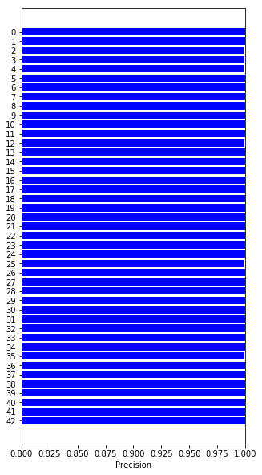

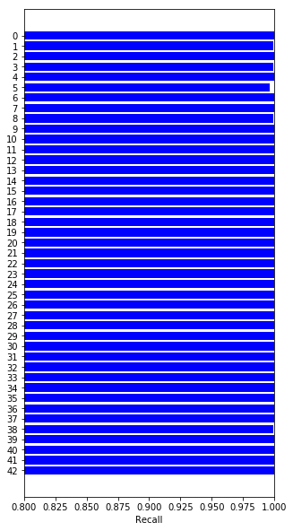

```python
from sklearn.metrics import precision_recall_fscore_support

#Precision and Recall calculation for Train dataset
with tf.Session() as sess:
    saver.restore(sess, tf.train.latest_checkpoint('.'))
    num_examples = len(X_train)
    y_pred = np.zeros((num_examples))

    for offset in range(0, num_examples, BATCH_SIZE):
        end = offset + BATCH_SIZE
        batch_x, batch_y = X_train[offset:end], y_train[offset:end]
        y_pred[offset:end] = sess.run(result_prediction, feed_dict={x: batch_x, y: batch_y, keep_prob: 1})

    precision_recall_fscore = precision_recall_fscore_support(y_train, y_pred, average=None, labels= list(range(43)))

    # Create a histogram for precision.
    fig, ax = plt.subplots(figsize = (5,10))
    labels= list(range(43))
    y_pos = np.arange(len(labels))
    probabilities = precision_recall_fscore[0]

    ax.barh(y_pos, probabilities, align='center',
                color='blue', ecolor='black')
    ax.set_yticks(y_pos)
    ax.set_yticklabels(labels)
    ax.invert_yaxis()
    ax.set_xlabel('Precision')
    plt.xlim((0.8,1))

    # Create a histogram for recall.
    fig, ax = plt.subplots(figsize = (5,10))
    labels= list(range(43))
    y_pos = np.arange(len(labels))
    probabilities = precision_recall_fscore[1]

    ax.barh(y_pos, probabilities, align='center',
                color='blue', ecolor='black')
    ax.set_yticks(y_pos)
    ax.set_yticklabels(labels)
    ax.invert_yaxis()
    ax.set_xlabel('Recall')
    plt.xlim((0.8,1))
```

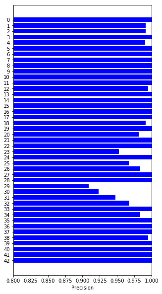

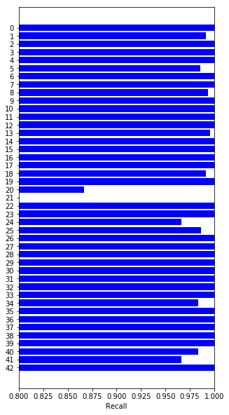

```python
#Precision and Recall calculation for Validation dataset
with tf.Session() as sess:
    saver.restore(sess, tf.train.latest_checkpoint('.'))
    num_examples = len(X_valid)
    y_pred = np.zeros((num_examples))

    for offset in range(0, num_examples, BATCH_SIZE):
        end = offset + BATCH_SIZE
        batch_x, batch_y = X_valid[offset:end], y_valid[offset:end]
        y_pred[offset:end] = sess.run(result_prediction, feed_dict={x: batch_x, y: batch_y, keep_prob: 1})

    precision_recall_fscore = precision_recall_fscore_support(y_valid, y_pred, average=None, labels= list(range(43)))

    # Create a histogram for precision.
    fig, ax = plt.subplots(figsize = (5,10))
    labels= list(range(43))
    y_pos = np.arange(len(labels))
    probabilities = precision_recall_fscore[0]

    ax.barh(y_pos, probabilities, align='center',
                color='blue', ecolor='black')
    ax.set_yticks(y_pos)
    ax.set_yticklabels(labels)
    ax.invert_yaxis()
    ax.set_xlabel('Precision')
    plt.xlim((0.8,1))

    # Create a histogram for recall.
    fig, ax = plt.subplots(figsize = (5,10))
    labels= list(range(43))
    y_pos = np.arange(len(labels))
    probabilities = precision_recall_fscore[1]

    ax.barh(y_pos, probabilities, align='center',
                color='blue', ecolor='black')
    ax.set_yticks(y_pos)
    ax.set_yticklabels(labels)
    ax.invert_yaxis()
    ax.set_xlabel('Recall')
    plt.xlim((0.8,1))
```

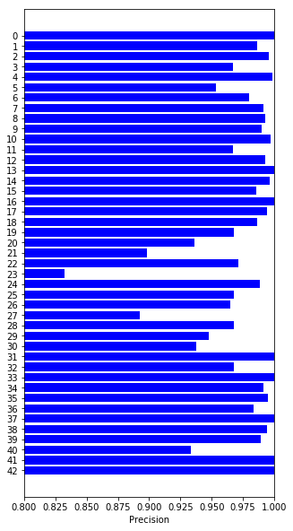

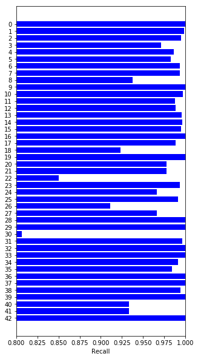

```python
#Precision and Recall calculation for Test dataset
with tf.Session() as sess:
    saver.restore(sess, tf.train.latest_checkpoint('.'))
    num_examples = len(X_test)
    y_pred = np.zeros((num_examples))

    for offset in range(0, num_examples, BATCH_SIZE):
        end = offset + BATCH_SIZE
        batch_x, batch_y = X_test[offset:end], y_test[offset:end]
        y_pred[offset:end] = sess.run(result_prediction, feed_dict={x: batch_x, y: batch_y, keep_prob: 1})

    precision_recall_fscore = precision_recall_fscore_support(y_test, y_pred, average=None, labels= list(range(43)))

    # Create a histogram for precision.
    fig, ax = plt.subplots(figsize = (5,10))
    labels= list(range(43))
    y_pos = np.arange(len(labels))
    probabilities = precision_recall_fscore[0]

    ax.barh(y_pos, probabilities, align='center',
                color='blue', ecolor='black')
    ax.set_yticks(y_pos)
    ax.set_yticklabels(labels)
    ax.invert_yaxis()
    ax.set_xlabel('Precision')
    plt.xlim((0.8,1))

    # Create a histogram for recall.
    fig, ax = plt.subplots(figsize = (5,10))
    labels= list(range(43))
    y_pos = np.arange(len(labels))
    probabilities = precision_recall_fscore[1]

    ax.barh(y_pos, probabilities, align='center',
                color='blue', ecolor='black')
    ax.set_yticks(y_pos)
    ax.set_yticklabels(labels)
    ax.invert_yaxis()
    ax.set_xlabel('Recall')
    plt.xlim((0.8,1))
```

### Output Top 5 Softmax Probabilities For Each Image Found on the Web

For each of the new images, print out the model's softmax probabilities to show the **certainty** of the model's predictions (limit the output to the top 5 probabilities for each image). [`tf.nn.top_k`](https://www.tensorflow.org/versions/r0.12/api_docs/python/nn.html#top_k) could prove helpful here.

The example below demonstrates how tf.nn.top_k can be used to find the top k predictions for each image.

`tf.nn.top_k` will return the values and indices (class ids) of the top k predictions. So if k=3, for each sign, it'll return the 3 largest probabilities (out of a possible 43) and the correspoding class ids.

Take this numpy array as an example. The values in the array represent predictions. The array contains softmax probabilities for five candidate images with six possible classes. `tk.nn.top_k` is used to choose the three classes with the highest probability:

```
# (5, 6) array
a = np.array([[ 0.24879643,  0.07032244,  0.12641572,  0.34763842,  0.07893497,
         0.12789202],
       [ 0.28086119,  0.27569815,  0.08594638,  0.0178669 ,  0.18063401,
         0.15899337],
       [ 0.26076848,  0.23664738,  0.08020603,  0.07001922,  0.1134371 ,
         0.23892179],
       [ 0.11943333,  0.29198961,  0.02605103,  0.26234032,  0.1351348 ,
         0.16505091],
       [ 0.09561176,  0.34396535,  0.0643941 ,  0.16240774,  0.24206137,
         0.09155967]])
```

Running it through `sess.run(tf.nn.top_k(tf.constant(a), k=3))` produces:

```
TopKV2(values=array([[ 0.34763842,  0.24879643,  0.12789202],
       [ 0.28086119,  0.27569815,  0.18063401],
       [ 0.26076848,  0.23892179,  0.23664738],
       [ 0.29198961,  0.26234032,  0.16505091],
       [ 0.34396535,  0.24206137,  0.16240774]]), indices=array([[3, 0, 5],
       [0, 1, 4],
       [0, 5, 1],
       [1, 3, 5],
       [1, 4, 3]], dtype=int32))
```

Looking just at the first row we get `[ 0.34763842, 0.24879643, 0.12789202]`, you can confirm these are the 3 largest probabilities in `a`. You'll also notice `[3, 0, 5]` are the corresponding indices.

```python
# Print out the top five softmax probabilities for the predictions on the new images
with tf.Session() as sess:
    saver.restore(sess, tf.train.latest_checkpoint('.'))
    softmax_probabilities = sess.run(tf.nn.top_k(sess.run(softmax, feed_dict={x: X_test_own, y: y_test_own, keep_prob: 1}), k=5))
    print(softmax_probabilities)
```

```
TopKV2(values=array([[  9.99998093e-01,   6.72479871e-07,   4.03967874e-07,
          3.34454285e-07,   2.09126355e-07],
       [  1.00000000e+00,   3.66302757e-08,   1.40504053e-09,
          5.08679820e-10,   2.80460849e-10],
       [  9.99995232e-01,   2.92025607e-06,   1.28569775e-06,
          2.24239400e-07,   1.98982121e-07],
       [  9.99893546e-01,   8.71033626e-05,   1.40341535e-05,
          2.43458749e-06,   1.50919504e-06],
       [  9.99999881e-01,   8.46648689e-08,   2.54584620e-08,
          8.92582452e-09,   8.73162254e-09],
       [  9.99998689e-01,   4.46433518e-07,   3.27551362e-07,
          2.65580638e-07,   9.53030650e-08],
       [  9.99999046e-01,   4.69644391e-07,   3.61795145e-07,
          1.00252016e-07,   1.34537865e-08],
       [  1.00000000e+00,   3.00577696e-08,   2.45690543e-08,
          1.50984061e-08,   1.49458348e-08],
       [  9.99995470e-01,   3.65950905e-06,   6.53349616e-07,
          2.06833946e-07,   4.15413268e-08],
       [  9.99997854e-01,   7.81069105e-07,   3.19058103e-07,
          2.96239648e-07,   2.47295930e-07],
       [  9.97497022e-01,   1.87523535e-03,   5.47372212e-04,
          4.84514712e-05,   1.38120922e-05],
       [  9.95054841e-01,   2.93908804e-03,   6.99838449e-04,
          4.20101511e-04,   3.07979295e-04]], dtype=float32), indices=array([[35, 34, 37, 33, 36],
       [17, 14,  9, 41, 40],
       [36, 34, 35, 38, 18],
       [ 2,  1,  5,  3,  7],
       [13, 12,  2, 15, 38],
       [16,  5,  9,  7,  0],
       [12,  9, 40, 13,  2],
       [14, 33, 17,  1,  8],
       [ 0,  1,  8,  4, 37],
       [23, 19, 25, 30, 11],
       [29, 23, 31, 25, 22],
       [40,  1, 23, 37, 11]]))
```

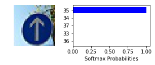

[figure not shown]

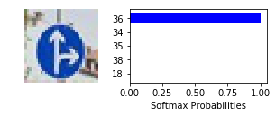

[figure not shown]

[figure not shown]

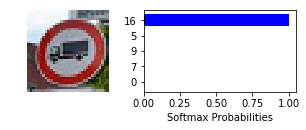

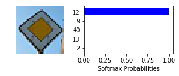

[figure not shown]

[figure not shown]

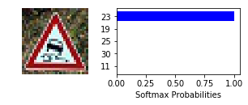

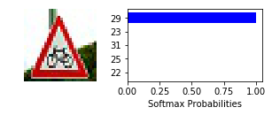

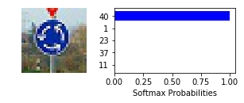

```python
# Here we create plots for the top5 softmax probabilities for each of the new images
import matplotlib.gridspec as gridspec

with tf.Session() as sess:
    # Restore saves session
    saver.restore(sess, tf.train.latest_checkpoint('.'))
    # Get Softmax probabilities for the new images
    softmax_probabilities = sess.run(tf.nn.top_k(sess.run(softmax, feed_dict={x: X_test_own, y: y_test_own, keep_prob: 1}), k=5))
    # Create plot for each individual image
    i=0
    for imageName in os.listdir("test_images/"):
        image = mpimg.imread('test_images/' + imageName)
        plt.figure(figsize = (5,1.5))
        gs = gridspec.GridSpec(1, 2,width_ratios=[2,3])
        plt.subplot(gs[0])
        plt.imshow(image)
        plt.axis('off')
        ax = plt.subplot(gs[1])
        labels = softmax_probabilities.indices[i]
        y_pos = np.arange(len(labels))
        probabilities = softmax_probabilities.values[i]

        ax.barh(y_pos, probabilities, align='center',
                color='blue', ecolor='black')
        ax.set_yticks(y_pos)
        ax.set_yticklabels(labels)
        ax.invert_yaxis()  # labels read top-to-bottom
        ax.set_xlabel('Softmax Probabilities')
        i += 1
plt.show()
```

## Step 4: Visualize the Neural Network's State with Test Images

This Section is not required to complete but acts as an additional excersise for understaning the output of a neural network's weights. While neural networks can be a great learning device they are often referred to as a black box. We can understand what the weights of a neural network look like better by plotting their feature maps. After successfully training your neural network you can see what it's feature maps look like by plotting the output of the network's weight layers in response to a test stimuli image. From these plotted feature maps, it's possible to see what characteristics of an image the network finds interesting. For a sign, maybe the inner network feature maps react with high activation to the sign's boundary outline or to the contrast in the sign's painted symbol.

For an example of what feature map outputs look like, check out NVIDIA's results in their paper [End-to-End Deep Learning for Self-Driving Cars](https://devblogs.nvidia.com/parallelforall/deep-learning-self-driving-cars/) in the section Visualization of internal CNN State. NVIDIA was able to show that their network's inner weights had high activations to road boundary lines by comparing feature maps from an image with a clear path to one without. Try experimenting with a similar test to show that your trained network's weights are looking for interesting features, whether it's looking at differences in feature maps from images with or without a sign, or even what feature maps look like in a trained network vs a completely untrained one on the same sign image.

[figure not shown]

Your output should look something like this (above)